# Thermal_analysis

Steve Rolfe

23 October 2015

Standard code to clear the system and install required libraries

```r
rm(list=ls())
library(ggplot2)
library(lubridate)
library(dplyr)
library(zoo)
```

Set up standard files names and the subset to plot

```r
setwd("C:/Users/Steve Rolfe/Google Drive/Phenomics/Thermal_analysis")
input_file="./data/thermal imaging.csv"
output_file="./output/BR7_thermal_out.csv"
plant_codes="./data/BR7_plant_codes.csv"

#subset of data to plot using grep format
sset<-"BR7-0[1-5]1[1-3][1-4]"
```

Set up standard headers for the files - these need to be edited to be consistent The BR codes are suppled by IBERS but we should include the ASSYT codes where possible Standard headers should be BR_code,date_time, measurements (with informative names) Custom code will be needed to translate the BR_codes into useful information

Read in the data and check that the required headers are there

```r
#read in the data
tdata<-read.csv(input_file,header=TRUE,stringsAsFactors = FALSE)
if(is.object(tdata)==FALSE) {stop(c("Can't open file:",input_file))}

#check that there the required headings are there and throw an error if not
if(is.na(match("BR_code",colnames(tdata)))){stop("BR_code missing from input file header")}
if(is.na(match("date_time",colnames(tdata)))){stop("date_time missing from input file header")}
head(tdata)
```

```
##     BR_code         date_time avg_leaf_temp env_temp
## 1 BR7-01111 2015-8-5 00:00:00      19.91836     22.3
## 2 BR7-01112 2015-8-5 00:00:00      20.04784     22.3
## 3 BR7-01113 2015-8-5 00:00:00      19.83152     22.3
## 4 BR7-01114 2015-8-5 00:00:00      19.68320     22.3
## 5 BR7-01121 2015-8-5 00:00:00      20.02428     22.3
## 6 BR7-01122 2015-8-5 00:00:00      19.89512     22.3
```

```r
#this file contains info about the plants used
plant_codes<-read.csv(plant_codes,header = TRUE,stringsAsFactors = FALSE)
if(is.object(plant_codes)==FALSE) {stop(c("Can't open file:",plant_codes))}
```

We deal with any specific coding here about names of plants, spores etc. Use the file plant_codes to keep the information organised

```r
#dpi offset from first data point
#it's good to express everything as dpi but 1st data point might not be dpi
#set the date of infection
dpi_datetime<-"2015-7-6 00:00:00"

#now set the factors manually
tdata$BR_code<-as.factor(tdata$BR_code)

#and set the plants,spores,etc
#the plant code is the sixth character in the BR7 string
tdata$plant<-as.factor(substr(tdata$BR_code,6,6))
#the spore concentration code is the 8th character
tdata$spore<-as.factor(substr(tdata$BR_code,8,8))
#the repeat is the 9th
tdata$rep<-as.factor(substr(tdata$BR_code,9,9))
head(tdata)
```

```
##     BR_code         date_time avg_leaf_temp env_temp plant spore rep
## 1 BR7-01111 2015-8-5 00:00:00      19.91836     22.3     1     1   1
## 2 BR7-01112 2015-8-5 00:00:00      20.04784     22.3     1     1   2
## 3 BR7-01113 2015-8-5 00:00:00      19.83152     22.3     1     1   3
## 4 BR7-01114 2015-8-5 00:00:00      19.68320     22.3     1     1   4
## 5 BR7-01121 2015-8-5 00:00:00      20.02428     22.3     1     2   1
## 6 BR7-01122 2015-8-5 00:00:00      19.89512     22.3     1     2   2
```

```r
#now merge the plant names with the data frame
tdata<-merge(tdata,plant_codes,by.x="plant",by.y="plant_code")
head(tdata)
```

```
##   plant   BR_code         date_time avg_leaf_temp env_temp spore rep
## 1     1 BR7-01111 2015-8-5 00:00:00      19.91836     22.3     1   1
## 2     1 BR7-01112 2015-8-5 00:00:00      20.04784     22.3     1   2
## 3     1 BR7-01113 2015-8-5 00:00:00      19.83152     22.3     1   3
## 4     1 BR7-01114 2015-8-5 00:00:00      19.68320     22.3     1   4
## 5     1 BR7-01121 2015-8-5 00:00:00      20.02428     22.3     2   1
## 6     1 BR7-01122 2015-8-5 00:00:00      19.89512     22.3     2   2
##    plant_name    ASSYST
## 1 OSR Cracker Sheff-001
## 2 OSR Cracker Sheff-001
## 3 OSR Cracker Sheff-001
## 4 OSR Cracker Sheff-001
## 5 OSR Cracker Sheff-001
## 6 OSR Cracker Sheff-001
```

```r
#now do some standard time processing
#use difftime to get the days since inoculation
tdata$dpi<-difftime(tdata$date_time,dpi_datetime,units="days")
#make it a factor when we just have a few days (but not when we want a continuous x scale)
tdata$dpi<-as.factor(tdata$dpi)
```

Always use a subset function to keep things under control for plotting

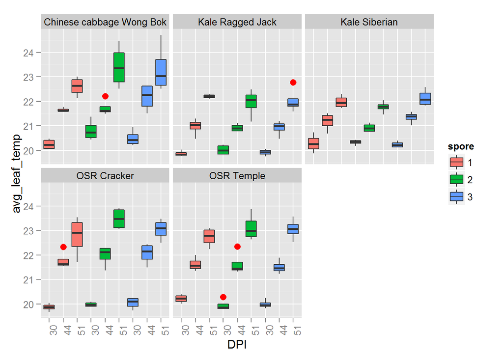

```r
subdata<-subset(tdata,grepl(sset,tdata$BR_code))
subdata<-droplevels(subdata)
#plot the raw data as a boxplot
p1<-ggplot(subdata,aes(x=interaction(dpi,spore),avg_leaf_temp))
p1<-p1+geom_boxplot(aes(fill=spore),outlier.colour="red",outlier.size=3)
p1<-p1+facet_wrap(~plant_name)

#the labels are untidy
new_labels<-rep(levels(as.factor(subdata$dpi)),length(levels(as.factor(subdata$spore))))

p1<-p1+scale_x_discrete(labels=new_labels,name="DPI")
p1<-p1+theme(axis.text.x=element_text(angle=90))
p1
```

The biggest effect here is the impact of day-to-day variation on temperatures We can correct for these by taking the difference from the average of the control (spore = 1)

```r
#use the summarise function to calculate the average for each treatment
t<-summarise(group_by(subdata,plant,spore,dpi),mean_temp=mean(avg_leaf_temp))
t
```

```
## Source: local data frame [45 x 4]
## Groups: plant, spore [?]
##
##     plant  spore    dpi mean_temp
##    (fctr) (fctr) (fctr)     (dbl)
## 1       1      1     30  19.87023
## 2       1      1     44  21.78968
## 3       1      1     51  22.76579
## 4       1      2     30  19.98098
## 5       1      2     44  21.97903
## 6       1      2     51  23.48294
## 7       1      3     30  20.04635
## 8       1      3     44  22.06269
## 9       1      3     51  23.04056
## 10      2      1     30  20.21808
## ..    ...    ...    ...       ...
```

```r
#we only want the spore 1 data
t<-subset(t,spore==1)
t$int<-interaction(t$plant,t$dpi)
t$plant<-NULL
t$spore<-NULL
t$dpi<-NULL
#now merge with subdata
#merge doesn't like the interaction function so we need to add a new column and merge by that

subdata$int<-interaction(subdata$plant,subdata$dpi)
subdata<-merge(subdata,t,by="int")

#now calculate the difference
subdata<-mutate(subdata,diff_temp=avg_leaf_temp-mean_temp)
```

Now plot

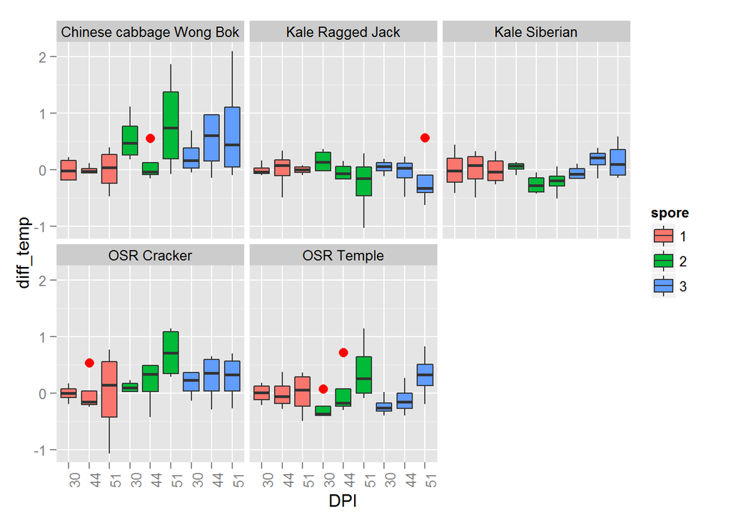

```r
#plot the processed data as a boxplot
p2<-ggplot(subdata,aes(x=interaction(dpi,spore),diff_temp))
p2<-p2+geom_boxplot(aes(fill=spore),outlier.colour="red",outlier.size=3)
p2<-p2+facet_wrap(~plant_name)

#the labels are untidy
new_labels<-rep(levels(as.factor(subdata$dpi)),length(levels(as.factor(subdata$spore))))

p2<-p2+scale_x_discrete(labels=new_labels,name="DPI")
p2<-p2+theme(axis.text.x=element_text(angle=90))
p2
```

Alternatively, calculate the difference between the leaf temperature and the environment

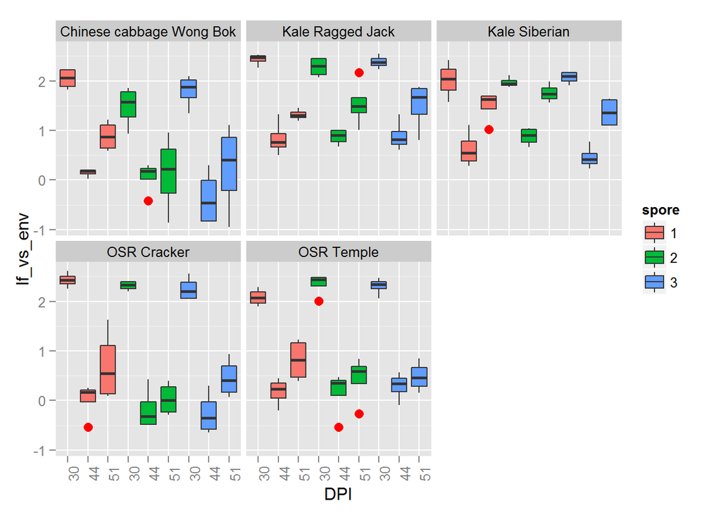

```r
subdata<-mutate(subdata,lf_vs_env=env_temp-avg_leaf_temp)
p3<-ggplot(subdata,aes(x=interaction(dpi,spore),lf_vs_env))
p3<-p3+geom_boxplot(aes(fill=spore),outlier.colour="red",outlier.size=3)
p3<-p3+facet_wrap(~plant_name)
#the labels are untidy
new_labels<-rep(levels(as.factor(subdata$dpi)),length(levels(as.factor(subdata$spore))))
p3<-p3+scale_x_discrete(labels=new_labels,name="DPI")
p3<-p3+theme(axis.text.x=element_text(angle=90))
p3
```

Now output the processed data

```r
write.csv(subdata,output_file)
```